# Simple Regression

Simulating an Experiment to Understand Assumptions

William Murrah

8/27/2020

```r
library(arm)
```

Here I will simulate data from a hypothetical experiment to demonstrate the assumptions of linear regression.

Recall the population equation for simple regression:

$$Y_i = \alpha + \beta X_i + \varepsilon_i$$

## Assumptions

Before we simulate the data, let’s summarize the assumptions of linear models (see Pedhazur, Chapter 2, or another textbook on regression for more details on these assumptions)..

### No Measurement Error

The independent variable is measured without error, meaning the predictor is assumed to be perfectly reliable.

### Linear Relation

The relation between the dependent and independent variables is assumed to be linear. In other words, the means of $Y$ at each level of $X$ are assumed to lie on a straight line.

### Dependent Variable is a Random Variable

We assume that $Y$ is a random variable, which means that it can take on a range of values, each having an associated probability.

### Unbiased Errors

We assume the errors have a mean of zero.

### Homogeneity of Variance

We assume the variance of $Y$ is constant at every level of $X$ in the population.

### Errors are not correlated with the independent variable $X$

We assume there is no correlation between the errors and the values of $X$.

### Independent Variable is Fixed

We assume (for now) that the independent variable $X$ is fixed, meaning that if the researcher were to replicate the study, the same values of $X$ would be used.

```r
a <- 5.05
b <- .75
sigma <- 2.45
# Sample size (multiple of )
n <- 1e5
```

```r
studyHrs <- rep(0:4, each = n/5)

set.seed(1234)
mathAch <- a + b*studyHrs + rnorm(n, 0, sigma)
```

```r
mod <- lm(mathAch ~ studyHrs)
```

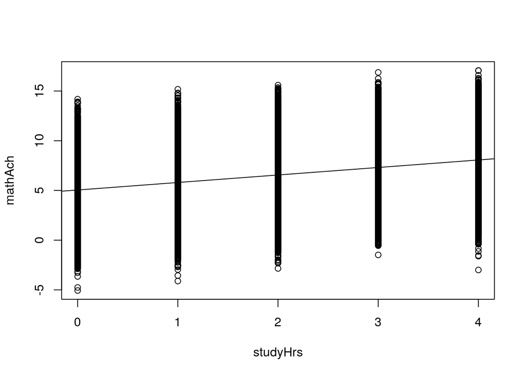

```r
plot(mathAch ~ studyHrs)
abline(coef(mod))
```

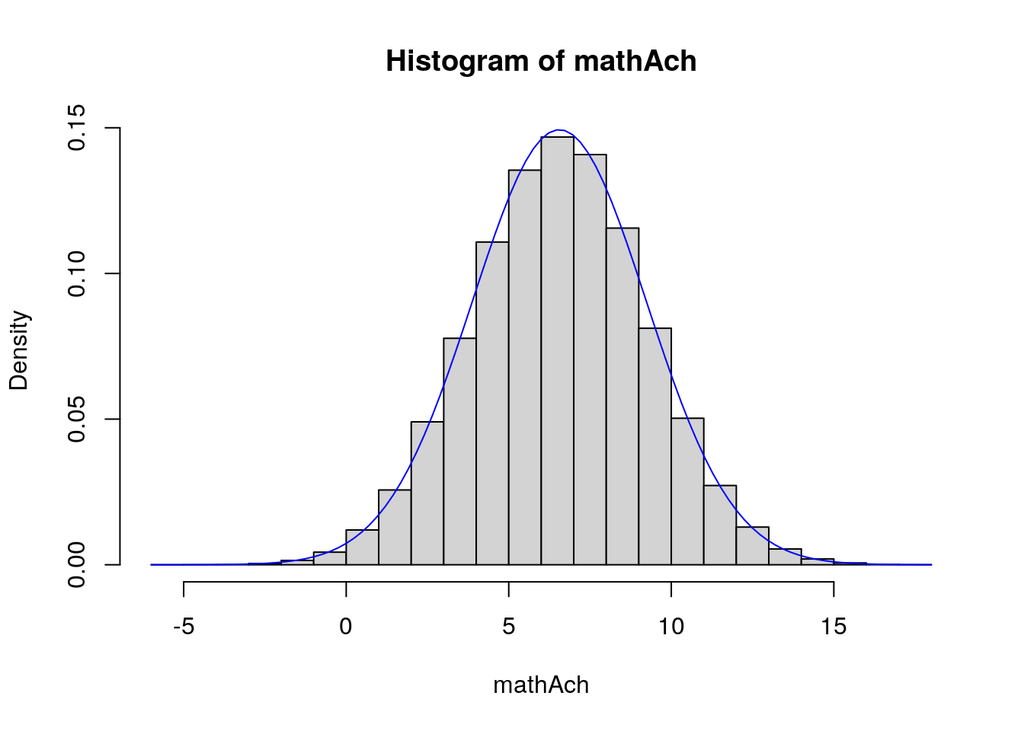

```r
hist(mathAch, probability = TRUE)
curve(dnorm(x, mean(mathAch), sd(mathAch)), add = TRUE, col = "blue")
```

```r
mod <- lm(mathAch ~ studyHrs)
display(mod)
```

```
lm(formula = mathAch ~ studyHrs)
            coef.est coef.se
(Intercept) 5.05     0.01
studyHrs    0.75     0.01
---
n = 100000, k = 2
residual sd = 2.45, R-Squared = 0.16
```

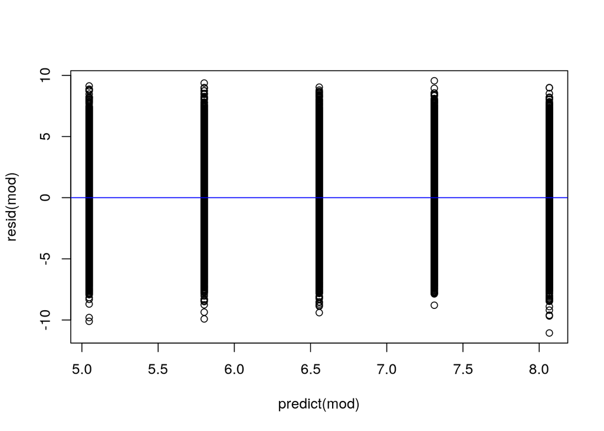

```r
mns <- aggregate(resid(mod) ~ studyHrs, FUN = mean)
plot(resid(mod) ~ predict(mod))
abline(h = 0, col = "blue")
```